# Импорт данных

### Импорт данных

До этого момента мы либо создавали какой-то набор данных, либо использовали какие-то встроенные датасеты. В реальной жизни все намного сложнее. Данные нужно откуда-то брать. Прежде чем говорить об источниках данных, давайте дадим определение. **Импорт данных** – это загрузка в среду R различных данных для последующей работы с ними. Важно понимать откуда мы берём данные. Обычно источником импорта выступают:

[figure not shown]

1. Обычные файлы (.csv, .txt).
2. Excel (.xlsx, .xls)
3. Базы данных (SQL).
4. Интернет.
5. Статистические пакеты (SPSS, SAS, STATA)

### Директория

Директория – это место (папка), где находится ваш “проект”. То есть там лежит скрипт, данные, картинки и прочее. Когда вы хотите загрузить данные с файлика, вам нужно прописать путь к нему, но если он находится в вашей директории, то можно просто напиать его название.

После загрузки всех необходимых пакетов, нужно узнать в какой директории вы находитесь. Это можно сделать несколькими способами:

1. Текущая директория написана в консоли.

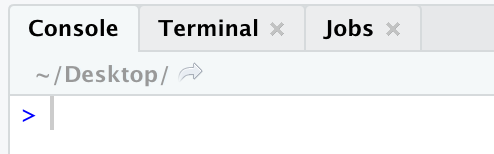

2. C помощью функцию `getwd()`.

Зачастую, у каждого проекта своя директория, поэтому приходится часто их менять. Есть несколько способов это сделать:

1. Использовать функция `setwd("~/Desktop/R")`, где в кавычках можно прописать путь к директории.
2. На панели R нажать кнопку *Session* и в выпадающем списке выбрать *Set Working Directory*. После чего вы можете выбрать нужную папку.
3. В нижнем правом окошке есть вся файловая система компьютера, где так же удобно можно установить нужную директорию. Нажав кнопку *More*, можно перейти в текущую директорию или установить новую.

Я рекомендую именно второй способ, потому что он быстрее , и вам не нужно знать путь. Чтобы проверить, что вы находитесь в нужной директории можно использовать функцию `dir()`. Она показывает все объекты которые находятся в директории.

### Импорт файлов с расширениями csv, txt и другими

#### Функция read.csv()

Формат *.csv* самый распространенный формат хранения данных в мире для анализа данных. Его можно получить, например, сохранив *excel* файл в формате *csv(разделитель - запятая)*. Перед тем как подгружать файл, нужно открыть файл в текстовом редакторе и посмотреть его структуру. Нужно обратить внимание на:

1. Наличие шапки (то есть имеются ли названия столбцов).
2. Тип разделителя (чем отделены друг от друга переменные).

Если вы часто работаете в разных директориях, советую прописать путь к файлу в отдельную переменную `path`. Для этого можно использовать функцию `file.path(‘~’, ‘data’, ‘data.csv’)`, но все таки лучше копировать путь из свойств файла. Также важно отметить про то, что *Windows* ставит слэш в обратную сторону.

Давайте разберем функцию `read.csv()`. Можно вызвать справку и узнать об этой функции побольше.

```r
?read.csv
```

Можно увидеть, что у этой функции достаточно много аргументов. Давайте посмотрим только на те, которые нам нужны.

> `read.csv(path, header = TRUE, sep = ",", stringAsFactors = TRUE, dec = '.')`

Аргументы (дефолтное значение):

- `path` – путь к файлу
- `header` (`TRUE`) – есть ли в файле наименования столбцов
- `sep` (`','`) – разделитель между переменными
- `stringAsFactors` (`TRUE`) – сделать ли столбец строковых переменных в факторный
- `dec` (`'.'`) – разделитель для числовых переменных (точка или запятая)

У нас есть файлик *friends.csv*. Попробуем подгрузить его.

##### Попытка №1

А давайте просто укажем файл и забьем на все эти параметры.

```r
data <- read.csv('data/friends.csv')
data
```

```
##         Jack.19.M.10.May.2000.7 X6
## 1  Emma;21;F;22 February 1998;8  9
## 2 Henry;18;M;3 September 2001;8  0
## 3      Aria;20;F;26 June 1999;9  3
```

```r
str(data)
```

```
## 'data.frame':    3 obs. of  2 variables:
##  $ Jack.19.M.10.May.2000.7: chr  "Emma;21;F;22 February 1998;8" "Henry;18;M;3 September 2001;8" "Aria;20;F;26 June 1999;9"
##  $ X6                     : int  9 0 3
```

R неправильно прочитал файл. Он думает, что у нас есть всего два столбца. Почему так вышло? Если открыть файл в текстовом редакторе, то можно увидеть, что разделителем между переменными является `";"`.

##### Попытка №2

Теперь мы поняли свою ошибку. Давайте её исправим

```r
data <- read.csv('data/friends.csv', sep = ';')
data
```

```
##    Jack X19 M     X10.May.2000 X7.6
## 1  Emma  21 F 22 February 1998  8,9
## 2 Henry  18 M 3 September 2001  8,0
## 3  Aria  20 F     26 June 1999  9,3
```

```r
str(data)
```

```
## 'data.frame':    3 obs. of  5 variables:
##  $ Jack        : chr  "Emma" "Henry" "Aria"
##  $ X19         : int  21 18 20
##  $ M           : chr  "F" "M" "F"
##  $ X10.May.2000: chr  "22 February 1998" "3 September 2001" "26 June 1999"
##  $ X7.6        : chr  "8,9" "8,0" "9,3"
```

Ой! У нас всего 3 наблюдения, хотя было 4. Это произошло, так как первая строчка стала названием столбцом. Почему так вышло? Давайте исправим это.

##### Попытка №3

```r
data <- read.csv('data/friends.csv', sep = ';', header = FALSE)
data
```

```
##      V1 V2 V3               V4  V5
## 1  Jack 19  M      10 May 2000 7,6
## 2  Emma 21  F 22 February 1998 8,9
## 3 Henry 18  M 3 September 2001 8,0
## 4  Aria 20  F     26 June 1999 9,3
```

```r
str(data)
```

```
## 'data.frame':    4 obs. of  5 variables:
##  $ V1: chr  "Jack" "Emma" "Henry" "Aria"
##  $ V2: int  19 21 18 20
##  $ V3: chr  "M" "F" "M" "F"
##  $ V4: chr  "10 May 2000" "22 February 1998" "3 September 2001" "26 June 1999"
##  $ V5: chr  "7,6" "8,9" "8,0" "9,3"
```

Если взглянуть на данные, то кажется, что всё прекрасно. Но это не так!

##### Попытка №4

Попробуем сделать всё так, как нужно!

```r
data <- read.csv('data/friends.csv', sep = ';', header = FALSE,
                 dec = ',', stringsAsFactors = FALSE,
                 col.names = c('Name', 'Age', 'Gender', 'Birthday', 'Homework grade'))
data
```

```
##    Name Age Gender         Birthday Homework.grade
## 1  Jack  19      M      10 May 2000            7.6
## 2  Emma  21      F 22 February 1998            8.9
## 3 Henry  18      M 3 September 2001            8.0
## 4  Aria  20      F     26 June 1999            9.3
```

```r
str(data)
```

```
## 'data.frame':    4 obs. of  5 variables:
##  $ Name          : chr  "Jack" "Emma" "Henry" "Aria"
##  $ Age           : int  19 21 18 20
##  $ Gender        : chr  "M" "F" "M" "F"
##  $ Birthday      : chr  "10 May 2000" "22 February 1998" "3 September 2001" "26 June 1999"
##  $ Homework.grade: num  7.6 8.9 8 9.3
```

Все выглядит почти идеально. Изменим тип переменной *Gender* на факторный, а также переменную *Birthday* на дату.

```r
# install.packages('lubridate')
library(lubridate)
data$Birthday <- dmy(data$Birthday)
data$Gender <- factor(data$Gender)
str(data)
```

```
## 'data.frame':    4 obs. of  5 variables:
##  $ Name          : chr  "Jack" "Emma" "Henry" "Aria"
##  $ Age           : int  19 21 18 20
##  $ Gender        : Factor w/ 2 levels "F","M": 2 1 2 1
##  $ Birthday      : Date, format: "2000-05-10" "1998-02-22" ...
##  $ Homework.grade: num  7.6 8.9 8 9.3
```

Если вы хотите использовать разделитель `;`, то можно использовать функцию `read.csv2`, которая использует этот разделитель по умолчанию, а также `dec = ","`.

Иногда бывают данные, где столбец это год. Например, у вас есть временной ряд за 1960 - 1976 года. Писать название каждого столбца утомительно. Можно воспользоваться функцией `paste0`.

```r
paste0("year_", 1960:1976)
```

```
##  [1] "year_1960" "year_1961" "year_1962" "year_1963" "year_1964" "year_1965"
##  [7] "year_1966" "year_1967" "year_1968" "year_1969" "year_1970" "year_1971"
## [13] "year_1972" "year_1973" "year_1974" "year_1975" "year_1976"
```

Помним, что обычный *data frame* не терпит пробелов в названиях переменных. Можно ставить нижнее подчеркивание (`_`).

#### Функция read.delim() и read.table()

Нужно сказать сначала то, что функции `read.delim` и `read.csv` это дочерние функции от функции `read.table`. Как мы уже убедились `read.csv` создан для файлов с расширением csv. А вот `read.delim` создан для файлов с расширением *.txt*. Если у вас есть какое-то другое расширение, то вы можете использовать `read.table` с нужными вам параметрами.

#### Функция read.delim()

`/t` – знак табуляции (один из видов разделителей). В `read.delim` он используется по умолчанию.

```r
data <- read.delim('data/friends.txt', dec = ',', header = FALSE,
                   stringsAsFactors = FALSE,
                   col.names = c('Name', 'Age', 'Gender', 'Birthday', 'Homework grade'))
data
```

```
##    Name Age Gender         Birthday Homework.grade
## 1  Jack  19      M      10 May 2000            7.6
## 2  Emma  21      F 22 February 1998            8.9
## 3 Henry  18      M 3 September 2001            8.0
## 4  Aria  20      F     26 June 1999            9.3
```

```r
str(data)
```

```
## 'data.frame':    4 obs. of  5 variables:
##  $ Name          : chr  "Jack" "Emma" "Henry" "Aria"
##  $ Age           : int  19 21 18 20
##  $ Gender        : chr  "M" "F" "M" "F"
##  $ Birthday      : chr  "10 May 2000" "22 February 1998" "3 September 2001" "26 June 1999"
##  $ Homework.grade: num  7.6 8.9 8 9.3
```

Аналогично есть функция `read.delim2`.

#### Функция read.table()

Если открыть файл `friends2.txt` можно увидеть, что разделитель это слэш (`/`). С помощью `read.table` мы можем задать нужный нам разделитель.

```r
data <- read.table('data/friends2.txt', sep = '/', dec = ',',
                   header = FALSE, stringsAsFactors = FALSE,
                   col.names = c('Name', 'Age', 'Gender', 'Birthday', 'Homework grade'))
data
```

```
##    Name Age Gender         Birthday Homework.grade
## 1  Jack  19      M      10 May 2000            7.6
## 2  Emma  21      F 22 February 1998            8.9
## 3 Henry  18      M 3 September 2001            8.0
## 4  Aria  20      F     26 June 1999            9.3
```

```r
str(data)
```

```
## 'data.frame':    4 obs. of  5 variables:
##  $ Name          : chr  "Jack" "Emma" "Henry" "Aria"
##  $ Age           : int  19 21 18 20
##  $ Gender        : chr  "M" "F" "M" "F"
##  $ Birthday      : chr  "10 May 2000" "22 February 1998" "3 September 2001" "26 June 1999"
##  $ Homework.grade: num  7.6 8.9 8 9.3
```

### Пакет readr

#### Установка и чтение пакетов

Давайте для начала установим и прочитаем пакет, а также пакет `dplyr`.

```r
#install.packages('readr')
# install.packages("dplyr")
library(readr)
library(dplyr)
```

#### Плюсы пакета и основые функции

Зачем нам вообще этот пакет, ведь мы умеем читать файлы с расширением *.csv*, *.txt* и их разновидностями?.

Здесь важно использовать определенную функцию для определенного разделителя. Мы рассмотрим функции `read_csv()` и `read_csv2()`.

Давайте попробуем подгрузить файл, который подгружали ранее.

```r
data <- read_csv2('data/friends.csv',
                  col_names = c('Name', 'Age', 'Gender', 'Birthday', 'Homework grade'))
glimpse(data)
```

```
## Rows: 4
## Columns: 5
## $ Name             <chr> "Jack", "Emma", "Henry", "Aria"
## $ Age              <dbl> 19, 21, 18, 20
## $ Gender           <chr> "M", "F", "M", "F"
## $ Birthday         <chr> "10 May 2000", "22 February 1998", "3 September 2001…
## $ `Homework grade` <dbl> 7.6, 8.9, 8.0, 9.3
```

Все получилось! Видим, что оценка за ДЗ подгрузилась как число. Аргумент `col_names` может принимать значение `FALSE`, если у нас нет названий переменных.

Изучим 2 новых аргумента:

- `comment` – знак комментария в файле
- `skip` – количество строк, которые нужно пропустить

```r
data <- read_csv2('data/friends2.csv', comment = '#',
                  col_names = c('Name', 'Age', 'Gender', 'Birthday', 'Homework grade'))
```

Или можно просто пропустить 1 строку.

```r
data <- read_csv2('data/friends2.csv', skip = 1,
                  col_names = c('Name', 'Age', 'Gender', 'Birthday', 'Homework grade'))
```

Функции этого пакета определяют тип переменных в столбце следующим образом: они берут первые 1000 наблюдений и используют к нему функцию `guess_parser()`, которая определяет к какому типу относится переменная. А функция `parse_guess()` преобразовывает вектор к нужному типу.

```r
guess_parser(c("True", "False"))
```

```
## [1] "logical"
```

```r
parse_guess(c("True", "False"))
```

```
## [1]  TRUE FALSE
```

```r
guess_parser(c("1.2", "2.12"))
```

```
## [1] "double"
```

```r
parse_guess(c("1.2", "2.12"))
```

```
## [1] 1.20 2.12
```

#### Скорость работы

Давайте проверим сокрость этого пакета. С помощью функции `Sys.time()` будем измерять время загрузки файла. Будем использовать файл *nir.csv*. В нем имеются данные о российских корпоративных облигациях. Весит этот файл 50 мегабайт. Это средний размер файла, но уже здесь мы почувствуем разницу.

Посчитаем время использования функции `read.csv()`:

```r
start <- Sys.time()
data <- read.csv('data/nir.csv')
finish <- Sys.time()

print(finish-start)
```

```
## Time difference of 20.90118 secs
```

Видим приблизительно 20.9 секунды. Представьте, что вы меняете и запускаете код постоянно. Хотелось бы, чтобы загрузка занимала меньше времени.

Теперь посчитаем время использования аналогичной функции `read_csv()` из пакета `readr`:

```r
start <- Sys.time()
data <- read_csv2('data/nir.csv')
finish <- Sys.time()

print(finish-start)
```

```
## Time difference of 7.804004 secs
```

Время уменьшилось до 7.8 секунд!

#### Проблемы больших файлов

В больших файлах иногда бывают проблемы. Например, первые 1000 значений `NA`. А с 1001 идут вещественные числа. Столбцу дадут тип `logical`. Можно увеличить количество значений с помощью аргумента `guess_max`.

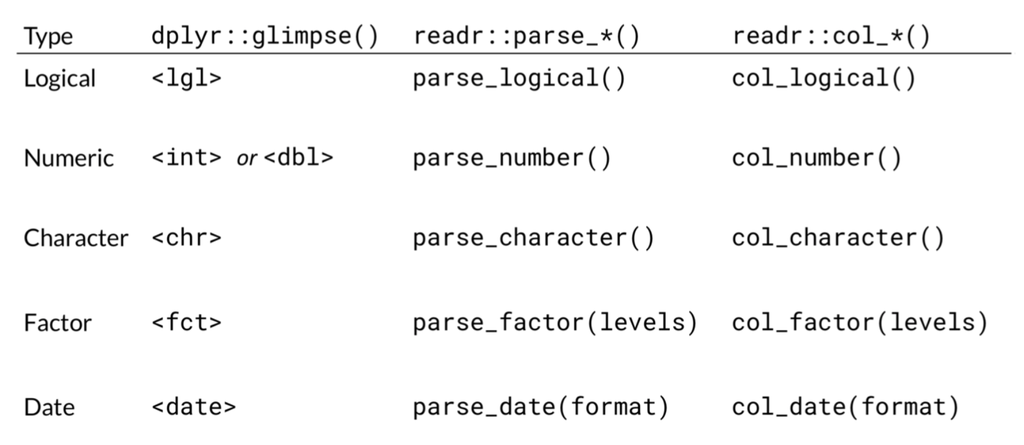

```r
data <- read_csv2('data/nir.csv', col_types = cols(
                                YLD_YTM_MID = col_double() ,
                                YLD_CNV_MID = col_double()
                  ))
```

Иногда проблемных мест бывает очень много. Поэтому бывает полезно прочитать все переменные как строковые.

```r
data <- read_csv2('data/nir.csv', col_types = cols(.default = col_character()))
```

#### Пропущенные значения

Почти в любых наборах данных, которые приходится импортировать бывают пропущенные значения. По умолчанию функция `read_csv()` считает пропущенными значениями "" и “NA”. Это можно исправить с помощью аругмента `na`. Представьте, что в наборе данных пропущенные значения помечаются как “UNKNOWN”, “NA” и "". Тогда можно преобразовать их следующим образом.

```r
data <- read_csv2('data/friends_na.csv', na = c("", "NA", "UNKNOWN"), col_names = F)
```

#### Подгрузка файлов из интернета

Можно подгружать файлы из интернета по url.

```r
data <- read_csv2('https://raw.githubusercontent.com/ahmedushka7/R/master/docs/scripts/hse_data_analysis/sem_7/data/friends.csv', col_names = F)
data
```

```
## # A tibble: 4 x 5
##   X1       X2 X3    X4                  X5
##   <chr> <dbl> <chr> <chr>            <dbl>
## 1 Jack     19 M     10 May 2000        7.6
## 2 Emma     21 F     22 February 1998   8.9
## 3 Henry    18 M     3 September 2001   8
## 4 Aria     20 F     26 June 1999       9.3
```

#### Экспорт данных

Данные нужно уметь не только импортировать, но и экспортировать. Для этого можно использовать функцию `write_csv()`. У нее имеется два важных аргумента:

- `x` – датасет (*data frame*), который у вас есть в памяти
- `path` – путь и название файла (если оставить только название файла, то файл сохранится в текущей директории)

Давайте сохраним набор `mtcars`.

```r
write_csv(mtcars, 'data/mtcars.csv')
```

Если вы планируете работать с вашим *.csv* файлом далее в *excel*, то рекомендуется использовать функцию `write_excel_csv()`, чтобы избежать проблем с кодировкой. Она работает аналогично функции `write_csv`.

Также существует функция `write_csv2()`, которая сохраняет файл с разделителем `";"`.

В этих функциях можно также передать аргумент `na`, в котором можно указать как должны выглядеть пропущенные значения в сохраняемом файле.

#### Кодировка

Пакет `readr` по умолчанию работает с кодировкой UTF-8. Если вы работаете со старым файлом, у которого другая кодировка, то вы можете использовать функцию `guess_encoding()`, которая может помочь узнать кодировку.

```r
guess_encoding("data/mtcars.csv")
```

```
## # A tibble: 1 x 2
##   encoding confidence
##   <chr>         <dbl>
## 1 ASCII             1
```

После того как вы узнали кодировку, вы можете передать ее в аргумент `locale`.

```r
data <- read_csv("data/mtcars.csv", locale = locale(encoding = 'ASCII'))
```